# Project: Dataset Investigation - Gapminder World

- Introduction
- Data Wrangling
- Exploratory Data Analysis
- Conclusions
- References

## Introduction

The Gapminder Foundation is a non-profit that promotes sustainable development by increased use of, and understanding of statistics. The organisation gathers information about how people live in different countries, tracked across the years, and on a number of different indicators.

For this project four variables are investigated, namely income per person (GDP/capita, PPP$ inflation-adjusted), fixed line subsribers (per 100 people) , cell phone (per 100 people) and broadband subscribers (per 100 people). An additional dataset is used to supplement country level geographical data. Further details on the aforementioned metrics, and how they were collected can be found in the links to the references sections of this report.

To improve readability the variables are abbreviated as follows:

> income per person (GDP/capita, PPP$ inflation-adjusted) : **income**

> fixed line subsribers (per 100 people) : **fixed**

> cell phone (per 100 people) : **phone**

> broadband subscribers (per 100 people) : **broadband**

A baseline understanding is first drawn by asking how each of the variables has changed for the period recorded. Further granularity is added to the analysis by grouping countries by continent. In addition to scrutinizing each variable indivually, the variables are evaluated in relation to each other.

```python
# import packages
import numpy as np
import pandas as pd
import matplotlib.pyplot as plt
import seaborn as sns
```

```python
# plot visualizations in notebook environment
%matplotlib inline
```

## Data Wrangling

### General Properties

```python
# Load data with four variables, plus supplementary dataset
df_income = pd.read_csv(r"C:\Users\noama\OneDrive\My Documents\OneDrive\Udacity\Project 2\income_per_person_gdppercapita_ppp_inflation_adjusted.csv")
df_fixed = pd.read_csv(r"C:\Users\noama\OneDrive\My Documents\OneDrive\Udacity\Project 2\fixed_line_subscribers_per_100_people.csv")
df_phone = pd.read_csv(r"C:\Users\noama\OneDrive\My Documents\OneDrive\Udacity\Project 2\cell_phones_per_100_people.csv")
df_broadband = pd.read_csv(r"C:\Users\noama\OneDrive\My Documents\OneDrive\Udacity\Project 2\broadband_subscribers_per_100_people.csv")
df_continent = pd.read_csv(r"C:\Users\noama\OneDrive\My Documents\OneDrive\Udacity\Project 2\datasets_14947_19943_countryContinent.csv", encoding="ISO-8859-1")
```

```python
#validate income dataset with inspection of first five rows
df_income.head()
```

|  | country | 1800 | 1801 | 1802 | 1803 | 1804 | 1805 | 1806 | 1807 | 1808 | ... | 2031 | 2032 | 2033 | 2034 | 2035 | 2036 | 2037 | 2038 | 2039 | 2040 |
| --- | --- | --- | --- | --- | --- | --- | --- | --- | --- | --- | --- | --- | --- | --- | --- | --- | --- | --- | --- | --- | --- |
| 0 | Afghanistan | 603 | 603 | 603 | 603 | 603 | 603 | 603 | 603 | 603 | ... | 2550 | 2600 | 2660 | 2710 | 2770 | 2820 | 2880 | 2940 | 3000 | 3060 |
| 1 | Albania | 667 | 667 | 667 | 667 | 667 | 668 | 668 | 668 | 668 | ... | 19400 | 19800 | 20200 | 20600 | 21000 | 21500 | 21900 | 22300 | 22800 | 23300 |
| 2 | Algeria | 715 | 716 | 717 | 718 | 719 | 720 | 721 | 722 | 723 | ... | 14300 | 14600 | 14900 | 15200 | 15500 | 15800 | 16100 | 16500 | 16800 | 17100 |
| 3 | Andorra | 1200 | 1200 | 1200 | 1200 | 1210 | 1210 | 1210 | 1210 | 1220 | ... | 73600 | 75100 | 76700 | 78300 | 79900 | 81500 | 83100 | 84800 | 86500 | 88300 |
| 4 | Angola | 618 | 620 | 623 | 626 | 628 | 631 | 634 | 637 | 640 | ... | 6110 | 6230 | 6350 | 6480 | 6610 | 6750 | 6880 | 7020 | 7170 | 7310 |

5 rows × 242 columns

```python
#validate fixed dataset with inspection of first five rows
df_fixed.head()
```

|  | country | 1960 | 1961 | 1962 | 1963 | 1964 | 1965 | 1966 | 1967 | 1968 | ... | 2009 | 2010 | 2011 | 2012 | 2013 | 2014 | 2015 | 2016 | 2017 | 2018 |
| --- | --- | --- | --- | --- | --- | --- | --- | --- | --- | --- | --- | --- | --- | --- | --- | --- | --- | --- | --- | --- | --- |
| 0 | Afghanistan | 0.0856 | NaN | NaN | NaN | NaN | 0.0934 | NaN | NaN | NaN | ... | 0.0181 | 0.057 | 0.0449 | 0.289 | 0.297 | 0.305 | 0.32 | 0.323 | 0.327 | 0.344 |
| 1 | Albania | 0.4180 | NaN | NaN | NaN | NaN | 0.7380 | NaN | NaN | NaN | ... | 12.2000 | 11.300 | 11.6000 | 10.700 | 9.680 | 8.140 | 7.84 | 8.610 | 8.550 | 8.620 |
| 2 | Algeria | NaN | NaN | NaN | NaN | NaN | 0.5790 | NaN | NaN | NaN | ... | 7.2900 | 8.120 | 8.3400 | 8.800 | 8.210 | 7.960 | 8.22 | 8.400 | 9.910 | 9.950 |
| 3 | Andorra | NaN | NaN | NaN | NaN | NaN | 2.7000 | NaN | NaN | NaN | ... | 44.9000 | 45.200 | 45.9000 | 46.500 | 47.800 | 48.300 | 49.80 | 50.100 | 49.900 | 51.100 |
| 4 | Angola | 0.1220 | NaN | NaN | NaN | NaN | 0.1730 | NaN | NaN | NaN | ... | 1.3500 | 1.200 | 0.6580 | 0.830 | 0.826 | 1.070 | 1.02 | 1.060 | 0.540 | 0.558 |

5 rows × 60 columns

```python
#validate phone dataset with inspection of first five rows
df_phone.head()
```

|  | country | 1960 | 1961 | 1962 | 1963 | 1964 | 1965 | 1966 | 1967 | 1968 | ... | 2009 | 2010 | 2011 | 2012 | 2013 | 2014 | 2015 | 2016 | 2017 | 2018 |
| --- | --- | --- | --- | --- | --- | --- | --- | --- | --- | --- | --- | --- | --- | --- | --- | --- | --- | --- | --- | --- | --- |
| 0 | Afghanistan | 0.0 | NaN | NaN | NaN | NaN | 0.0 | NaN | NaN | NaN | ... | 37.0 | 35.0 | 45.8 | 49.2 | 52.1 | 55.2 | 57.3 | 61.1 | 65.9 | 59.1 |
| 1 | Albania | 0.0 | NaN | NaN | NaN | NaN | 0.0 | NaN | NaN | NaN | ... | 82.9 | 91.3 | 106.0 | 120.0 | 127.0 | 116.0 | 118.0 | 117.0 | 126.0 | 94.2 |
| 2 | Algeria | 0.0 | NaN | NaN | NaN | NaN | 0.0 | NaN | NaN | NaN | ... | 92.6 | 91.1 | 97.1 | 100.0 | 104.0 | 111.0 | 109.0 | 116.0 | 111.0 | 112.0 |
| 3 | Andorra | 0.0 | NaN | NaN | NaN | NaN | 0.0 | NaN | NaN | NaN | ... | 76.4 | 77.6 | 77.7 | 77.5 | 79.1 | 83.6 | 91.4 | 98.5 | 104.0 | 107.0 |
| 4 | Angola | 0.0 | NaN | NaN | NaN | NaN | 0.0 | NaN | NaN | NaN | ... | 36.0 | 40.3 | 49.8 | 50.9 | 51.1 | 52.2 | 49.8 | 45.1 | 44.7 | 43.1 |

5 rows × 60 columns

```python
#validate broadband dataset with inspection of first five row
df_broadband.head()
```

|  | country | 1998 | 1999 | 2000 | 2001 | 2002 | 2003 | 2004 | 2005 | 2006 | ... | 2009 | 2010 | 2011 | 2012 | 2013 | 2014 | 2015 | 2016 | 2017 | 2018 |
| --- | --- | --- | --- | --- | --- | --- | --- | --- | --- | --- | --- | --- | --- | --- | --- | --- | --- | --- | --- | --- | --- |
| 0 | Afghanistan | NaN | NaN | NaN | NaN | NaN | NaN | 0.00081 | 0.00086 | 0.00189 | ... | 0.00352 | 0.00514 | NaN | 0.00481 | 0.00465 | 0.00449 | 0.0205 | 0.0249 | 0.0463 | 0.043 |
| 1 | Albania | NaN | NaN | NaN | NaN | NaN | NaN | NaN | 0.00881 | NaN | ... | 3.09000 | 3.58000 | 4.3800 | 5.49000 | 6.29000 | 7.18000 | 8.4000 | 9.2300 | 10.5000 | 12.600 |
| 2 | Algeria | NaN | NaN | NaN | NaN | NaN | 0.0558 | 0.11000 | 0.40700 | 0.50500 | ... | 2.32000 | 2.50000 | 2.6800 | 3.09000 | 3.36000 | 4.11000 | 5.7100 | 7.0500 | 7.7600 | 7.260 |
| 3 | Andorra | NaN | NaN | NaN | NaN | 1.64 | 4.9200 | 8.24000 | 13.10000 | 18.00000 | ... | 27.20000 | 29.00000 | 30.8000 | 32.60000 | 34.30000 | 36.30000 | 39.3000 | 42.0000 | 44.5000 | 46.300 |
| 4 | Angola | NaN | NaN | NaN | NaN | NaN | NaN | NaN | NaN | 0.03700 | ... | 0.06660 | 0.06420 | 0.0653 | 0.08170 | 0.08570 | 0.32600 | 0.5510 | 0.2940 | 0.3250 | 0.356 |

5 rows × 22 columns

```python
#validate continent dataset with inspection of first five rows
df_continent.head()
```

|  | country | code_2 | code_3 | country_code | iso_3166_2 | continent | sub_region | region_code | sub_region_code |
| --- | --- | --- | --- | --- | --- | --- | --- | --- | --- |
| 0 | Afghanistan | AF | AFG | 4 | ISO 3166-2:AF | Asia | Southern Asia | 142.0 | 34.0 |
| 1 | Åland Islands | AX | ALA | 248 | ISO 3166-2:AX | Europe | Northern Europe | 150.0 | 154.0 |
| 2 | Albania | AL | ALB | 8 | ISO 3166-2:AL | Europe | Southern Europe | 150.0 | 39.0 |
| 3 | Algeria | DZ | DZA | 12 | ISO 3166-2:DZ | Africa | Northern Africa | 2.0 | 15.0 |
| 4 | American Samoa | AS | ASM | 16 | ISO 3166-2:AS | Oceania | Polynesia | 9.0 | 61.0 |

### Obervations:

-income, fixed, phone and broadband datasets need to be tidied so that each row is an observation and each column a variable.

```python
#reshape income dataframe from wide to long format
df_income = pd.melt(df_income, id_vars='country', var_name='year', value_name='income')
df_income.head()
```

|  | country | year | income |
| --- | --- | --- | --- |
| 0 | Afghanistan | 1800 | 603 |
| 1 | Albania | 1800 | 667 |
| 2 | Algeria | 1800 | 715 |
| 3 | Andorra | 1800 | 1200 |
| 4 | Angola | 1800 | 618 |

```python
#reshape fixed dataframe from wide to long format
df_fixed = pd.melt(df_fixed, id_vars='country', var_name='year', value_name='fixed')
df_fixed.head()
```

|  | country | year | fixed |
| --- | --- | --- | --- |
| 0 | Afghanistan | 1960 | 0.0856 |
| 1 | Albania | 1960 | 0.4180 |
| 2 | Algeria | 1960 | NaN |
| 3 | Andorra | 1960 | NaN |
| 4 | Angola | 1960 | 0.1220 |

```python
#reshape phone dataframe from wide to long format
df_phone = pd.melt(df_phone, id_vars='country', var_name='year', value_name='phone')
df_phone.head()
```

|  | country | year | phone |
| --- | --- | --- | --- |
| 0 | Afghanistan | 1960 | 0.0 |
| 1 | Albania | 1960 | 0.0 |
| 2 | Algeria | 1960 | 0.0 |
| 3 | Andorra | 1960 | 0.0 |
| 4 | Angola | 1960 | 0.0 |

```python
#reshape broadband dataframe from wide to long format
df_broadband = pd.melt(df_broadband, id_vars='country', var_name='year', value_name='broadband')
df_broadband.head()
```

|  | country | year | broadband |
| --- | --- | --- | --- |
| 0 | Afghanistan | 1998 | NaN |
| 1 | Albania | 1998 | NaN |
| 2 | Algeria | 1998 | NaN |
| 3 | Andorra | 1998 | NaN |
| 4 | Angola | 1998 | NaN |

```python
#diplay number of columns and rows in each dataset
print("The income dataset contains " + str(df_income.shape[0]) + " rows and " + str(df_income.shape[1]) + " columns")
print("The fixed dataset contains " + str(df_fixed.shape[0]) + " rows and " + str(df_fixed.shape[1]) + " columns")
print("The phone dataset contains " + str(df_phone.shape[0]) + " rows and " + str(df_phone.shape[1]) + " columns")
print("The broadband dataset contains " + str(df_broadband.shape[0]) + " rows and " + str(df_broadband.shape[1]) + " columns")
print("The continent dataset contains " + str(df_continent.shape[0]) + " rows and " + str(df_continent.shape[1]) + " columns")
```

```
The income dataset contains 46513 rows and 3 columns
The fixed dataset contains 11446 rows and 3 columns
The phone dataset contains 11446 rows and 3 columns
The broadband dataset contains 4032 rows and 3 columns
The continent dataset contains 249 rows and 9 columns
```

### Observations:

-The income dataset contains the highest number of recorded observations, while the reverse is true for the broadband dataset (excluding the supplementary dataset). Said otherwise, income has the longest recorded history of obervations of the four variables. To facilitate a direct comparison between variables the merged dataset is trimmed to the number of observations recored in the smallest dataset (broadband).

```python
#join income dataset & fixed datasets together
income_fixed = df_income.merge(df_fixed, on=['country', 'year'])
income_fixed.head(1)
```

|  | country | year | income | fixed |
| --- | --- | --- | --- | --- |
| 0 | Afghanistan | 1960 | 2740 | 0.0856 |

```python
#add phone variable to dataset containing income & fixed variables
fixed_phone = income_fixed.merge(df_phone, on=['country', 'year'])
fixed_phone.head(1)
```

|  | country | year | income | fixed | phone |
| --- | --- | --- | --- | --- | --- |
| 0 | Afghanistan | 1960 | 2740 | 0.0856 | 0.0 |

```python
#add broadband variable to dataset containing income, fixed and phone variables
phone_broadband = fixed_phone.merge(df_broadband, on=['country', 'year'])
phone_broadband.head(1)
```

|  | country | year | income | fixed | phone | broadband |
| --- | --- | --- | --- | --- | --- | --- |
| 0 | Afghanistan | 1998 | 800 | 0.147 | 0.0 | NaN |

```python
#add continent data to dataset containing income, fixed, phone and broadband variables
df_all = phone_broadband.merge(df_continent, on='country')
df_all.head(1)
```

|  | country | year | income | fixed | phone | broadband | code_2 | code_3 | country_code | iso_3166_2 | continent | sub_region | region_code | sub_region_code |
| --- | --- | --- | --- | --- | --- | --- | --- | --- | --- | --- | --- | --- | --- | --- |
| 0 | Afghanistan | 1998 | 800 | 0.147 | 0.0 | NaN | AF | AFG | 4 | ISO 3166-2:AF | Asia | Southern Asia | 142.0 | 34.0 |

```python
#reorder columns and retain only those of interest
df = df_all.loc[:,['country', 'continent', 'year', 'income', 'fixed', 'phone', 'broadband']]
df.head(1)
```

|  | country | continent | year | income | fixed | phone | broadband |
| --- | --- | --- | --- | --- | --- | --- | --- |
| 0 | Afghanistan | Asia | 1998 | 800 | 0.147 | 0.0 | NaN |

```python
#display column names, dtype and number of missing values
df.info()
```

```
<class 'pandas.core.frame.DataFrame'>
Int64Index: 3486 entries, 0 to 3485
Data columns (total 7 columns):
 #   Column     Non-Null Count  Dtype
---  ------     --------------  -----
 0   country    3486 non-null   object
 1   continent  3486 non-null   object
 2   year       3486 non-null   object
 3   income     3486 non-null   int64
 4   fixed      3394 non-null   float64
 5   phone      3406 non-null   float64
 6   broadband  2586 non-null   float64
dtypes: float64(3), int64(1), object(3)
memory usage: 217.9+ KB
```

### Observations:

-The merged dataset contains 3486 rows (observations) and 7 columns (variables).

-The year variable can be converted to a data time object.

-fixed, phone and broadband variables contain missing values.

-income, fixed, phone, and broadband are quantitative variables that can be numerically analysed.

```python
#count number of missing values for fixed, phone and broadband columns
df.isnull().sum()
```

```
country        0
continent      0
year           0
income         0
fixed         92
phone         80
broadband    900
dtype: int64
```

### Data Cleaning

```python
# convert year column from object to date time object
df['year'] = pd.to_datetime(df.year)
```

```python
#drop observatitions with missing values across multiple variables
df.dropna(how='all', subset=['fixed', 'phone', 'broadband'], inplace=True)
df.isnull().sum()
```

```
country        0
continent      0
year           0
income         0
fixed         30
phone         18
broadband    838
dtype: int64
```

### Obervations:

-the variables fixed, phone and broadband now contain fewer variables that can be replaced.

```python
#fill missing values using interpolation
df.interpolate(method='linear', axis=0, inplace=True)
df.tail()
```

|  | country | continent | year | income | fixed | phone | broadband |
| --- | --- | --- | --- | --- | --- | --- | --- |
| 3481 | Zimbabwe | Africa | 2014-01-01 | 2510 | 2.42 | 86.8 | 1.12 |
| 3482 | Zimbabwe | Africa | 2015-01-01 | 2510 | 2.42 | 92.3 | 1.19 |
| 3483 | Zimbabwe | Africa | 2016-01-01 | 2490 | 2.18 | 91.8 | 1.22 |
| 3484 | Zimbabwe | Africa | 2017-01-01 | 2570 | 1.86 | 99.0 | 1.32 |
| 3485 | Zimbabwe | Africa | 2018-01-01 | 2620 | 1.86 | 89.4 | 1.41 |

## Exploratory Data Analysis

### Research Question 1: How have income, fixed, phone and broadband changed over time?

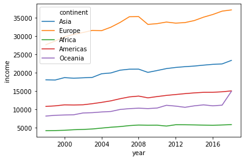

```python
#line plot of the variable income by continent
sns.lineplot('year', 'income', data=df, hue='continent', ci=None);
```

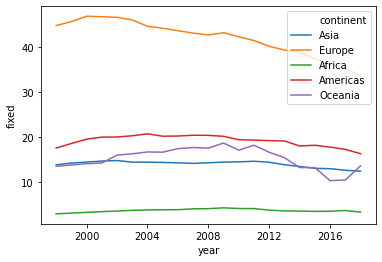

```python
#line plot of the variable fixed by continent
sns.lineplot('year', 'fixed', data=df, hue='continent', ci=None);
```

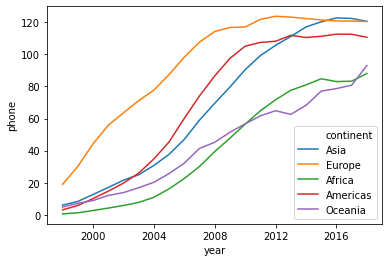

```python
#line plot of the variable phone by continent
sns.lineplot('year', 'phone', data=df, hue='continent', ci=None);
```

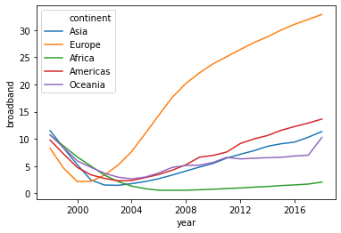

```python
#line plot of the variable broadband by continent
sns.lineplot('year', 'broadband', data=df, hue='continent', ci=None);
```

### Observations:

-fixed line connections have either remained steady or declined as a channel of communcation for the time period recorded

-phone connections saw explosive growth over the same time period, with some markets beginning to show evidence of saturation

-broadband connections declined at the beginning of the century, before recovering. Europe, again is at the forefront of this uptick

### Research Question 2: What is the shape of the distribution for the latest year for which data is available?

```python
#subset dataframe for year of interest (2018)
df_2018 = df.loc[df.year == '2018', :]
df_2018.head()
```

|  | country | continent | year | income | fixed | phone | broadband |
| --- | --- | --- | --- | --- | --- | --- | --- |
| 20 | Afghanistan | Asia | 2018-01-01 | 1740 | 0.344 | 59.1 | 0.043 |
| 41 | Albania | Europe | 2018-01-01 | 12300 | 8.620 | 94.2 | 12.600 |
| 62 | Algeria | Africa | 2018-01-01 | 13900 | 9.950 | 112.0 | 7.260 |
| 83 | Andorra | Europe | 2018-01-01 | 51500 | 51.100 | 107.0 | 46.300 |
| 104 | Angola | Africa | 2018-01-01 | 5730 | 0.558 | 43.1 | 0.356 |

```python
#summary stats on numerical columns for 2018
df_2018.describe()
```

|  | income | fixed | phone | broadband |
| --- | --- | --- | --- | --- |
| count | 147.000000 | 147.000000 | 147.000000 | 147.000000 |
| mean | 19908.462585 | 15.693578 | 108.234354 | 14.314086 |
| std | 20422.548500 | 17.212123 | 34.232195 | 14.602554 |
| min | 629.000000 | 0.000000 | 27.400000 | 0.001820 |
| 25% | 4335.000000 | 1.520000 | 87.250000 | 0.836500 |
| 50% | 12800.000000 | 12.000000 | 113.000000 | 9.660000 |
| 75% | 28750.000000 | 23.450000 | 132.000000 | 27.650000 |
| max | 113000.000000 | 112.000000 | 209.000000 | 51.200000 |

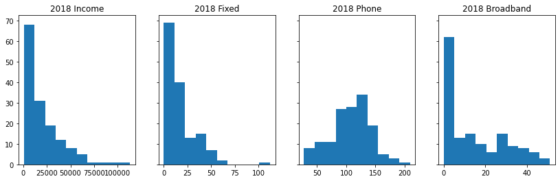

```python
# create array of values and assign to variable
w = df_2018.income.values
x = df_2018.fixed.values
y = df_2018.phone.values
z = df_2018.broadband.values

#create space for figure and subplots
fig, axs = plt.subplots(nrows=1, ncols=4, figsize= (14,4), sharey= True)

# draw histogram for each of the variables
axs[0].hist(w);
axs[1].hist(x);
axs[2].hist(y);
axs[3].hist(z);

#label title for each plot
axs[0].set_title('2018 Income')
axs[1].set_title('2018 Fixed')
axs[2].set_title('2018 Phone')
axs[3].set_title('2018 Broadband')
```

### Observations:

-The variables Income, Fixed and Broadband are skewed to the right, while the variable phone comes closest to resembling a normal distrubtion. Where skew is present, the median may be a more accurate measure of central tendency (most common value) than the mean.

### Research Question 3: How does the shape of the distribution differ across geographical regions for 2018?

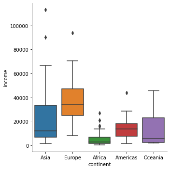

```python
#box plot of the variable income by continent
sns.catplot(x="continent", y="income", kind="box", data=df_2018);
```

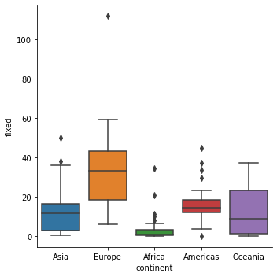

```python
#box plot of the variable fixed by continent
sns.catplot(x="continent", y="fixed", kind="box", data=df_2018);
```

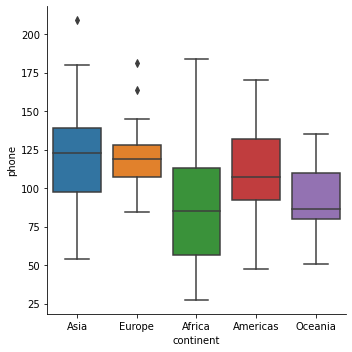

```python
#box plot of the varible phone by continent
sns.catplot(x="continent", y="phone", kind="box", data=df_2018);
```

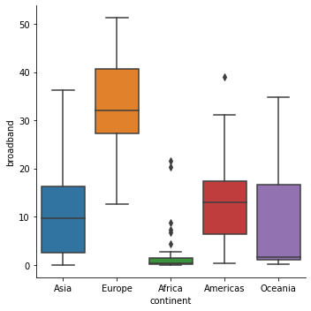

```python
#box plot of the variable broadband by continent
sns.catplot(x="continent", y="broadband", kind="box", data=df_2018);
```

### Observations:

-The IQR (middle 50 of the distribution) for broadband and phone is wider than it is for fixed and income

-The variable Phone demonstrates the greatest uniformity across continents

-The presence of outliers

### Research Question 4: What relationship, if any, is there between income, fixed, phone and broadband?

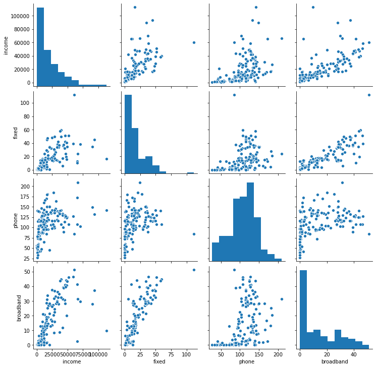

```python
sns.pairplot(df_2018);
```

### Observations:

-weak positive association betwen income and fixed and income and broadband

-moderate positive correlation between fixed and broadband

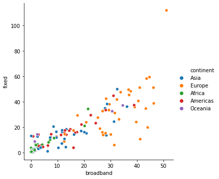

```python
#relationship plot for broadband and fixed by continent
sns.relplot(x="broadband", y="fixed", data=df_2018, hue='continent');
```

## Conclusions

#### Summary

> RQ2:
> 1. The distribution of Income, fixed, and broadband connections is skewed to the right, implying the presence of a few countries significantly different from the rest of the world.
> 2. The distribution of phone line connections is most equitable for phone line connections.

> RQ4:
> 1. There is evidence for a positive correlation between the level of income a country possess and the number of fixed and broadband connections.
> 2. There is also evidence to suggest the number of fixed line connections a country possess is positively correlated with the number of number of broad band connections.

#### Limitations

**Treatment of Missing Values**: Missing values were interpolated under the assumption that the realtionship is linear. Formal statistical techniques can be applied to assess the validity of such a claim.

Better yet, an investigation into the causes of the missing values may reveal systematic bias. In other words, an assessment could be made to to evaluate whether the values are missing at random. It may be that missing values are a placeholder for the value zero.For example it is etirely plausible that the missing value for Afganisain in 1998 under broadband connectivity is another way of stating that broadband was absent from the country at that moment in time. Replacing the missing value with the numeric zero would therefore be an accurate representation of reality.

**Outlier Treatment**: The numerical summary as well as the plot of distriubtions revealed outliers. Suffice it to say here that an entire literature has developed around investigating the cause, and proper treatment outliers.

## References

> 1. https://www.gapminder.org/data/
> 2. https://www.gapminder.org/data/documentation/gd001/
> 3. https://data.worldbank.org/indicator/IT.NET.BBND.P2
> 4. https://data.worldbank.org/indicator/IT.CEL.SETS.P2
> 5. https://data.worldbank.org/indicator/IT.NET.USER.ZS